# covid 19

Karen Hernandez

10/19/2020

### Data is from the Patient_Info dataset from South Korea 1 Jan to 1 May

### This is contained in a downloadable zip file from kaggle

Some of the data was uncoded for sex - sex must be just male or female 77 of the data entries were coded sex as blank, so we omit these. state of a patient must be died or alive - we adjust that as well

# Question 1 - Is dying independent of sex

Table of patients:

```r
# cross tabulation, patient state by gender

with(kRdata, table(Sex, result))
```

```
##    result
## Sex alive dead
##   F  1831   25
##   M  1411   44
```

## We create two bar charts - one based on frequency and the other on percent

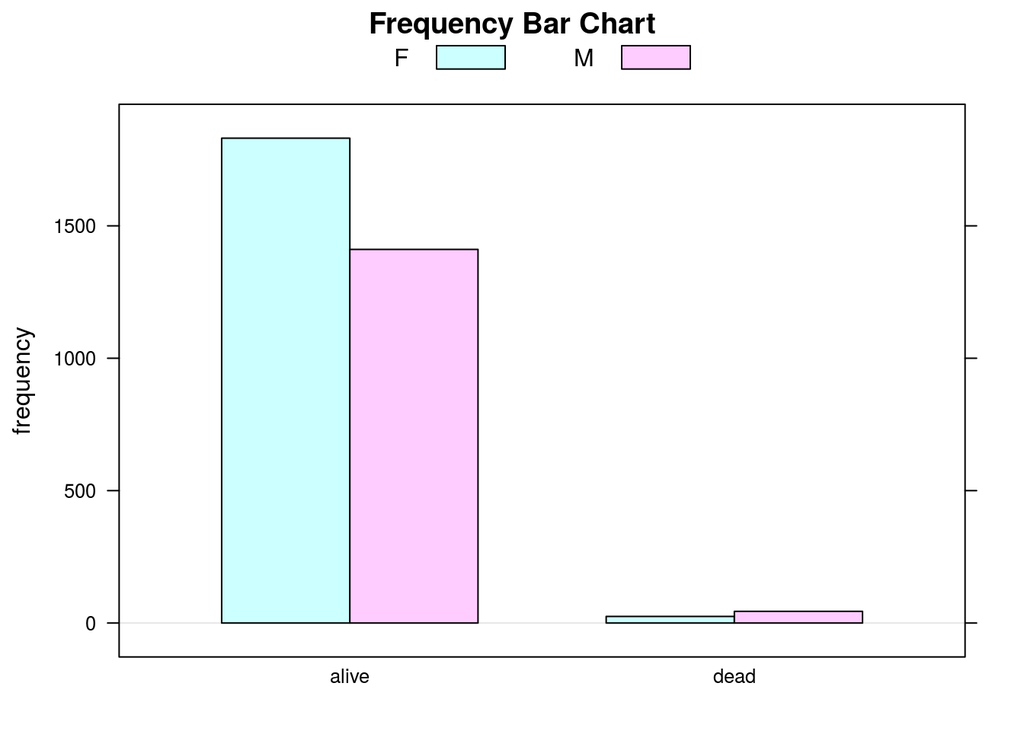

```r
barchartGC(~result + Sex,data=kRdata, main ="Frequency Bar Chart")
```

### this bar chart is displaying in total frequency terms our data. Clearly there are a lot less dead people than alive people as is reflected by the sizes of the bars in the display.

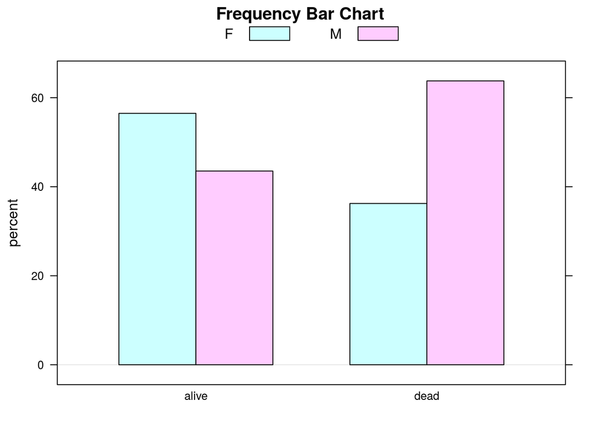

```r
barchartGC(~result + Sex,data=kRdata, type ="percent", main = "Frequency Bar Chart")
```

## Numerical results

```r
table1 <- xtabs(~result + Sex, data=kRdata)
rowPerc(table1)
```

```
##        Sex
## result    F   M Total
##   alive  56  44   100
##   dead   36  64   100
```

```r
colPerc(table1)
```

```
##        Sex
## result      F   M
##   alive  98.7  97
##   dead    1.4   3
##   Total 100.0 100
```

Of all the people who are alive, 56% of them are female and 44% of them are male. Of all the people who are dead, 36% of them are females and 64% of them are male.It looks like males are dying a lot more frequently than females are.

## Inferential results

```r
chisq.test(table1)
```

```
##
##  Pearson's Chi-squared test with Yates' continuity correction
##
## data:  table1
## X-squared = 10, df = 1, p-value = 0.001
```

```r
chisqtestGC(table1)
```

```
## Pearson's Chi-squared test with Yates' continuity correction
##
## Observed Counts:
##        Sex
## result     F    M
##   alive 1831 1411
##   dead    25   44
##
## Counts Expected by Null:
##        Sex
## result     F    M
##   alive 1817 1425
##   dead    39   30
##
## Contributions to the chi-square statistic:
##        Sex
## result     F    M
##   alive 0.10 0.13
##   dead  4.84 6.17
##
##
## Chi-Square Statistic = 10
## Degrees of Freedom of the table = 1
## P-Value = 0.0012
```

```r
fisher.test(table1)
```

```
##
##  Fisher's Exact Test for Count Data
##
## data:  table1
## p-value = 9e-04
## alternative hypothesis: true odds ratio is not equal to 1
## 95 percent confidence interval:
##  1.4 3.9
## sample estimates:
## odds ratio
##        2.3
```

This means 2.3 dies times greater as often as a women does. It is more deadly to men than women dying.

## Conclusions

All of that being said, we can see the results that show that males are more likely to die than females as a result of covid19. The results of the Fishers Exact test show that males are 2.3 times more likely to die than females. As a result, we will reject the null hypothesis stating that men and women are equally likely to die of covid19